# Whack a MoG

### 2) EM Function

This is the adjusted handmade.em function that works with k Gaussians. We have decided to stick with the code ([Brutti’s implementation](https://elearning.uniroma1.it/pluginfile.php/389598/course/section/166527/Topic%2013%20-%20Parametric%20Inference%20-%20MoG.R?time=1608629571077)) implemented by prof. Brutti, with the fallowing changes:

- k = is the input parameter that changes the number of Gaussians.
- m = is the input parameter used while plotting the functions to identify on which dataset the function is optimizing the parameters.
- likefunction = it is a function that computes the likelihood on the whole given dataset.
- d_tot, r_tot = correspond to r1, r2, d1 and d2 but, since we are dealing with more than two Gaussinas, they are matrices instead of numbers.

Moreover, all the other parameters (p, mu, sigma) have been treated as matrices since there are more than two Gaussians. Note: We left the calculation of the likelihood and the deviance in the handmade.em() function even though we don’t use them. They could be removed to speed up the computation.

We have considered to implement an early stopping condition by looking how the deviance changes throughout the iterations of the algorithm, but at the end we decided to simply use 200 iterations because sometimes the speed of convergence is slow and after more iterations it is possible to observe a significant improvement. Look at Appendix A for an example of this.

```r
handmade.em <- function(y, p, mu, sigma, n_iter, plot_flag = F, k, m){

  #function to compute the likelihood function
  likefunction <- function(y){
    like <- 0
    for (i in 1:k){
      like <- like + p[i]*dnorm(y, mu[i], sigma[i])
    }
    return(like)
  }

  like <- likefunction(y) #compute likelihood
  like[like<1e-300]=1e-300 #sometimes we get NaN when this number is 0 or really close to   it.
  #It happens rarely, most often when one of the points is really far from the           distribution.
  deviance <- -2*sum(log(like)) # compute deviance

  res      <- matrix(NA,n_iter + 1, 2+3*k)
  res[1,]  <- c(0, p, mu, sigma, deviance)

  d_tot <- rep.row(rep(NA,length(y)),k)
  r_tot <- rep.row(rep(NA,length(y)),k)

  for (iter in 1:n_iter) {

    # E step (get responsibilities)
    # responsibility = proportion times the Gaussian over the 2 found parameters
    for (j in 1:k) {d_tot[j,] <- pmax(p[j]*dnorm(y, mu[j], sigma[j]),1e-300)}
    # getting optimal hidden state (since it is proportionality we need to normalize)      distribution
    for (j in 1:k) {r_tot[j,] <- d_tot[j,]/sum.columns(d_tot)}

    # M step
    # here we compute the p, mean and sigma for each gaussian.
    for (j in 1:k){
      r = r_tot[j,]
      p[j]     <- mean(r)
      mu[j]    <- sum(r*y)/(sum(r))
      sigma[j] <- max(sqrt( sum(r*(y^2))/sum(r) - (mu[j])^2 ),1.0e-8)   #We don't want
      #a value of sigma too small to avoid computational errors.
      if (is.nan(sigma[j])) {
        sigma[j]=0.05
        print("NaN found in sigma[j]. Value reinitialized to 0.05")
        #Sometimes the sqrt in sigma[j] returns NaN. We decided to reinitialize that           sigma
        #value to 0.05 and hope it doesn't give NaN the second time.
      }
      }

    # -2 x log-likelihood (a.k.a. deviance)
    like <- pmax(likefunction(y),1e-30)    # update likelihood
    deviance <- -2*sum( log(like) )# update deviance

    # Save
    res[iter+1,] <- c(iter, p, mu, sigma, deviance)

    # Plot
    if (plot_flag && iter==n_iter){
      hist(y, prob = T, breaks=100,
           col = "pink", border = "white",
           main = paste("Bart Simpson Density, M=",m),
           xlab = paste("EM Iteration: ", iter, "/", n_iter, sep = ""))


     # add curves, colors and legend
      cols = rep(NA,k+1)
      cols[k+1] = "orange"
      # #iterate to plot every distribution
      for (i in 1:k) {
        cols[i] = rgb(runif(1),runif(1),runif(1),.8)
        curve(p[i]*dnorm(x,mu[i],sigma[i]),
                            lwd = 3,
                            lty = 5,
                            col = cols[i],
                            add = TRUE)}
      # add the join distribution
      curve(likefunction(x),
            lwd = 4, col = "orange", add = TRUE)
      # add the legend
      legendlabels=rep(NA,k+1)
      for (i in 1:k){legendlabels[i]=paste("Distribution ", i)}
      legendlabels[k+1] = "joint "

      legend('topright',legend=legendlabels,
             col=cols, lty=1, cex=0.6)
      grid()

    }
  }
  res <- data.frame(res)
  out <- list(parameters = c(p = p, mu = mu, sigma = sigma),
              deviance = deviance,
              res = res)
  return(out)
}
```

### 3) Multiple Initialization

Since the Mixture of Gaussians EM is very sensitive to the initialization parameters, there are multiple solutions that can be considered like:

- trying multiple initialization and keeping only the one that returns best results after the fit.

AND/OR

- finding an initialization method that returns good results more consistently. One could try using something like k-means++ initialization on the $\mu$ or, provided that one knows additional information about the data, it is possible to use a more specific initialization method. For example, in our case one could initialize one gaussian centered in zero and with a large $\sigma$ and then spread the others along the interval [-1;-1].

We have decided to initialize with simple uniform distribution for the parameters ($\mu$, $\sigma$) but we do that multiple times, keeping as results only the one that return a better results in terms of fitting. Instead, regarding the p parameter, we didn’t randomize its initialization but we assigned a value of 1/k each, where k is the number of Gaussians.

To understand why a good initialization is important, in Appendix B, we show 5 different results of the handmade.em() function, with different (random) initialization parameters. Notice how the one with the highest mean log-likelihood is the one that also better fits the data visually. It is important to highlight that the choice of initialization parameters is done on training set and not on the test.

### 4) AIC & BIC

The AIC_BIC() function represented below is the function used to score every MoG with the two metrics AIC and BIC. The function, after having optimized the parameter by calling the handmade.em() function, computes the AIC and BIC scores. It keeps, by calling the podium(), the top three k values (representing the number of gaussian forming each MoG) according to the AIC and BIC metrics.

```r
AIC_BIC <-function(Dataset,n_iter=500){
  AIC_models=list()
  BIC_models=list()

  AIC_results=rep(0,k_max)
  BIC_results=rep(0,k_max)


  for (j in 1:length(Dataset)){ #This cycle iterates over all samples
    XX <- Dataset[[j]]
    n <- length(XX)

    for (i in 1:k_max){ #This is the cycle that tries different number of gaussians

      #We now do a for loop to find the best initialization data for a particular
      #fixed k (number of gaussians) and for a fixed dataset XX.

      ll_sum <- -Inf  #This is a default initialization value. Every likelihood will be       better than this.

      for (w in 1:init_num){

        hem_fit_temp <- handmade.em(XX,
                               p      = rep(1/i,i),
                               mu     = runif(i,min=-1.5,max=1.5),
                               sigma  = runif(i,min=0.1,max=0.4),
                               n_iter = n_iter,
                               plot_flag = F,
                               k=i,
                               m=j)

        ll_temp<- likefunction(XX, hem_fit_temp) # compute log-likelihood on XX.

        if (sum(ll_temp) > ll_sum) { # if the new ll is better than the best we had              before
          ll <- ll_temp    # save new ll in the ll variable
          ll_sum <- sum(ll) # also compute the sum for the next iteration
          hem_fit <- hem_fit_temp # and save all the values returned by the EM                   algorithm.
        }

      }
      n_par=length(hem_fit$parameters)-1 # if one knows n-1 values for p, the last one       is forced
      #to be 1-(sum(p_i)). This means that there's one less degree of freedom in the         possible
      #values of p.
      AIC <- round(-2*sum(ll)+2*n_par,2) # compute AIC
      BIC <- round(-2*sum(ll) + log(n)*n_par,2) # compute BIC

      AIC_results[length(hem_fit$parameters)/3]=AIC
      BIC_results[length(hem_fit$parameters)/3]=BIC

    }
    AIC_models[[j]] <- podium(AIC_results)
    BIC_models[[j]] <- podium(BIC_results)
    remove(XX)
  }

  out <- list(AIC = AIC_models,
              BIC = BIC_models)
  return (out)
}
```

The AIC_results, BIC_results are two lists that store the AIC and BIC results.

```r
temp_result=AIC_BIC(data,n_iter=200)

AIC_results=temp_result$AIC
BIC_results=temp_result$BIC
```

### 5) Sample Splitting

The sample_splitting() function takes in input:

- the train_size (30%, 50% or 70% in our cases),
- all the data on which it has to work,
- the number of iterations.

Once it has returned the optimized parameters on the training sample by calling the handmade.em() function, it computes the log-likelihood on the train, and if was better than the one computed in the previous iteration, it also computes the log-likelihood on the test. At the end it returns, by calling the podium(), the top three k values (representing the number of gaussian forming each MoG) according to log-likelihood computed on the test set.

```r
#The structure of the code here is similar to the on in the AIC_BIC() function above.
sample_splitting <-function(train_size,Dataset,n_iter=500) {
  models=list()
  for (j in 1:length(Dataset))
    {
    dataset=Dataset[[j]]
    trainIndex<-createDataPartition(dataset, p = train_size,
                        list = FALSE,
                        times = 1) #We use the function "createDataPartition" from the                                        library "caret" to split the dataset in train and test.
    train <- dataset[trainIndex]
    test <- dataset[-trainIndex]

    results=rep(0,k_max) #array that will hold the results

    for (i in 1:k_max){ #cycle over the different number of gaussians.

      ll_sum <- -Inf

      #This is the cycle that will look for the best initialization data on the
      #TRAIN set for a fixed k (number of gaussians) value.
      for (w in 1:init_num)
        {
        hem_fit_temp <- handmade.em(train,
                                    p      = rep(1/i,i),
                                    mu     = runif(i,min=-1.5,max=1.5),
                                    sigma  = runif(i,min=0.1,max=0.4),
                                    n_iter = n_iter,
                                    plot_flag = F,
                                    k=i,
                                    m=j) #the em is called on the train sample.


        #We now compute the log likelihood with TRAIN
        ll_train<- likefunction(train, hem_fit_temp) # compute log-likelihood on the TRAIN

        if (sum(ll_train) > ll_sum) #if it was better than the last init parameters on
                                    #train then:
          {
            ll <- likefunction(test, hem_fit_temp) # compute log-likelihood on the TEST
            ll_sum <- sum(ll_train) #keep new best value for the ll on TRAIN
            hem_fit <- hem_fit_temp #keep all the resutls from this em run.
          }
      }
      #Now ll corresponds to the log-likelihood of the test dataset with the                 initialization data that had the best results on the train set
      results[length(hem_fit$parameters)/3]= -sum(ll) #store results for different k values in an array. We put "-" because our podium function takes the least 3 values.

    }

    models[[j]] <- podium(results) #keep best 3 results.

  }
  return (models)
}
```

Below are reported three lists containing the results for different train-test ratios.

```r
Sample_splitting30_results=sample_splitting(0.30,data,n_iter=200)
Sample_splitting50_results=sample_splitting(0.50,data,n_iter=200)
Sample_splitting70_results=sample_splitting(0.70,data,n_iter=200)
```

### 6) Cross Validation

The cv() function, is our implementation of CV-sample splitting. It keeps in input:

- x = a dataset.
- k_fold = the number of folds on which we want to our dataset to be splitted into.

It returns a list with the desired number of folds.

```r
cv <- function(x, k_fold){
  dataset <- x # copy the data set
  l = length(dataset) # get its length
  folds <- list() # list will contain all folds
  size <- as.integer(l/k_fold) # size of each fold
  for (n in 1:k_fold){ # iterate over all the desired folders
    fold_elements = c() # vector that will store elements
    while (length(fold_elements) < size){ # iterate until the fold size is reached
      idx_elm = sample(1:l, 1) # get index element
      fold_elements = c(fold_elements, dataset[idx_elm]) # add element to the vector
      dataset = dataset[-idx_elm] # drop element from data set
      l = length(dataset) # recompute the length
    }
    folds[[n]] = fold_elements  # add vector(representing the folder) to the folder list
  }
  if (l != 0){# if there are still data points
    for (m in 1:l){ #assign them one by one to the folders until are done
      folds[[m]] = c(folds[[m]], dataset[1]) # assign a data point to folder m
      dataset = dataset[-1] # delete it from the data set
    }
  }
  return(folds)
}
```

The cross_validation() function takes in input: * Dataset = a dataset

- k_folds = the number of folds on which we want to our dataset to split into. This parameter is necessary since this function calls internally the cv() function previously described.
- n_iter = the number of iteration for the handmade.em() function

As always, every time we do a fit we try different initialization and we return the one with the best log-likelihood. Of course, in this case we do that every time the validation test changes. For each k (where k always represent the number of gaussians composing the MoG) we have in our hands 5 or 10 log-likelihood computed on every different validation set (depending if we are dealing with 5-CV or 10-CV), then we compute the average and we store it into an array called results. We finally call the podium() function to return the top three k values (representing the number of gaussian forming each MoG) according to the average log-likelihood computed on the validation sets.

```r
#The structure of this function is similar to the sample splitting.

cross_validation<-function(Dataset,k_folds,n_iter){
  models=list()
  for (j in 1:length(Dataset))
  {
    dataset=Dataset[[j]]
    k_cv=cv(dataset, k_folds) #we create the folds with our function

    results=rep(0,k_max)   #array to store the results

    for (i in 1:k_max)
    {


      k_cv_results=rep(NA,k_folds) #array to store the results for a particular fold

      for (fold in 1:k_folds) #for each fold
        {
        test=k_cv[[fold]]  #split into test
        train=do.call(c,k_cv[-fold]) #and train


        ll_sum <- -Inf #initialize the "best likelihood". This will change when better initialziation parameters are found.

        #This is the cycle to find better initialization parameters.
        for (w in 1:init_num)
        {
          hem_fit_temp <- handmade.em(train,
                                      p      = rep(1/i,i),
                                      mu     = runif(i,min=-1.5,max=1.5),
                                      sigma  = runif(i,min=0.1,max=0.4),
                                      n_iter = n_iter,
                                      plot_flag = F,
                                      k=i,
                                      m=j)
          ll_train<- likefunction(train, hem_fit_temp) # compute log-likelihood with                                                          TRAIN
          if (sum(ll_train) > ll_sum)
          {
            ll <- likefunction(test, hem_fit_temp) # compute log-likelihood with TEST
            ll_sum <- sum(ll_train) #save best likelihood on TRAIN found until now
            hem_fit <- hem_fit_temp  #and the returned parameters for that particular                                            fitted model
          }
        }
        #Now ll corresponds to the log-likelihood of the test dataset with the                 inizialization data that had the best results on the train set

        k_cv_results[fold]=sum(ll) #store the result in this array


      }
      ll_mean=mean(k_cv_results) #get the mean log-likelihood over the k folds.
      results[length(hem_fit$parameters)/3]= -ll_mean #store mean in this array. We put
                                  # "-" because our podium function takes lowest 3 values.

    }
    models[[j]] <- podium(results) #call our function to get top 3 for each dataset.

  }
  return (models)
}
```

Below are reported two lists containing the results for the two different CVs.

```r
Cross_validation5_results=cross_validation(data,5,n_iter=200)
Cross_validation10_results=cross_validation(data,10,n_iter=200)
```

### 7) Wasserstein score

```r
Wasserstein_score <-function(Dataset,n_iter=500) {
  models=list()
  for (j in 1:length(Dataset))

  {
    results=rep(0,k_max) #array that will keep the results for each k

    dataset=Dataset[[j]]
    trainIndex<-createDataPartition(dataset, p = 0.5,
                                    list = FALSE,
                                    times = 1)
    train <- dataset[trainIndex] #split into train
    test <- dataset[-trainIndex] #and test

    #We define a function of a single variable. It corresponds to the quantile of our
    #empirical distribution. We use the test dataset for this.
    Quantile_to_integrate_te <-function(z) quantile(test,prob=z,names=FALSE)


    for (i in 1:k_max){

      ll_sum <- -Inf #initialize the "best likelihood". It will be update when better initialization parameters are found for a particular k.

      #This cycle is looking for the best initialization parameters for a particular k.
      for (w in 1:init_num)
      { hem_fit_temp <- handmade.em(train,
                                    p      = rep(1/i,i),
                                    mu     = runif(i,min=-1.5,max=1.5),
                                    sigma  = runif(i,min=0.1,max=0.4),
                                    n_iter = n_iter,
                                    plot_flag = F,
                                    k=i,
                                    m=j)
        ll_train<- likefunction(train, hem_fit_temp) # compute log-likelihood with TRAIN

        if (sum(ll_train) > ll_sum) #if we found a better log likelihood
        {
          ll <- ll_train #keep that ll
          ll_sum <- sum(ll_train) #the sum for further comparisons
          hem_fit <- hem_fit_temp #and all the returned parameters.
        }
      }
      #Now ll corresponds to the log-likelihood of the train dataset with the inizialization
      #data that had the best results on the train set

      #get the p, menas and sigma values.
      len=length(hem_fit$parameters)
      prob=hem_fit$parameters[1:(len/3)]
      means=hem_fit$parameters[(1+len/3):(2*len/3)]
      sigmas=hem_fit$parameters[(2*len/3+1):len]

      #define the quantile for a MoG with k values with the parameters got by em_fit
      Quantile_to_integrate_k <-function(z) qmixnorm(z, mean=means, pro=prob, sd=sigmas,expand=0.10)

      #integrate the absolute value of the difference between 0 and 1.
      function_to_integrate <-function(z) abs(Quantile_to_integrate_te(z)-Quantile_to_integrate_k(z))
      W_k=integrate(function_to_integrate,lower=0,upper=1,subdivisions = 10000)

      #and store the result in the array "results"
      results[length(hem_fit$parameters)/3]=W_k$value
    }

    models[[j]] <- podium(results) #keep top 3 models for a particular dataset.

  }
  return (models)

}
```

Below is returned the lists containing the results based on the Wasserstain score.

```r
Wasserstein_score_results=Wasserstein_score(data,n_iter=200)
```

Once all the scores are computed they will be stored into a list and a .csv file is written in order to return it every time is necessary.

```r
listHolder=list(AIC=AIC_results,
                BIC=BIC_results,
                Sample_splitting30=Sample_splitting30_results,
                Sample_splitting50=Sample_splitting50_results,
                Sample_splitting70=Sample_splitting70_results,
                Cross_validation5=Cross_validation5_results,
                Cross_validation10=Cross_validation10_results,
                Wesserstein_score=Wasserstein_score_results
                )
TO_SAVE= do.call(rbind, listHolder)
write.csv2(TO_SAVE,'listHolder2.csv')
print("finished")
```

### 8) Results

We now comment the result we got. At the end of this section there are 4 histogram visualizations of the obtained results. A full table, showing all the numerical results for all the metrics and grouped by sample sizes, is available in Appendix C.

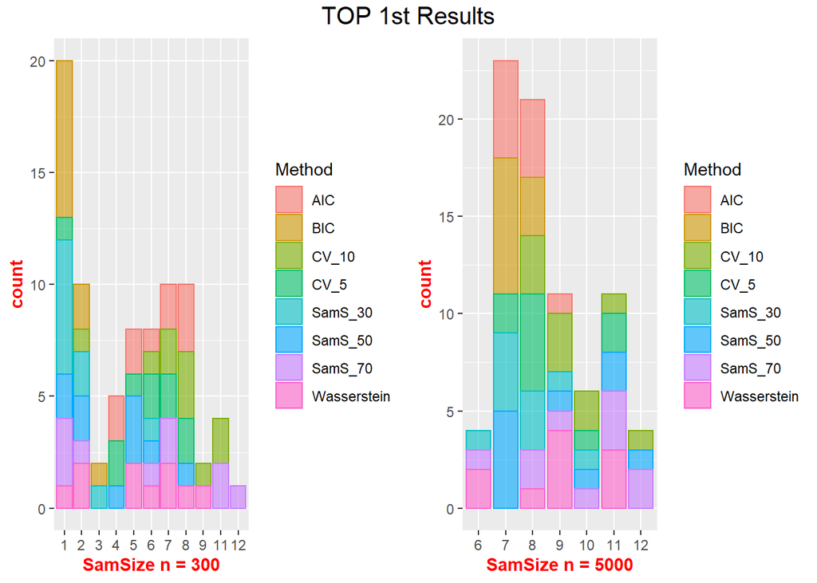

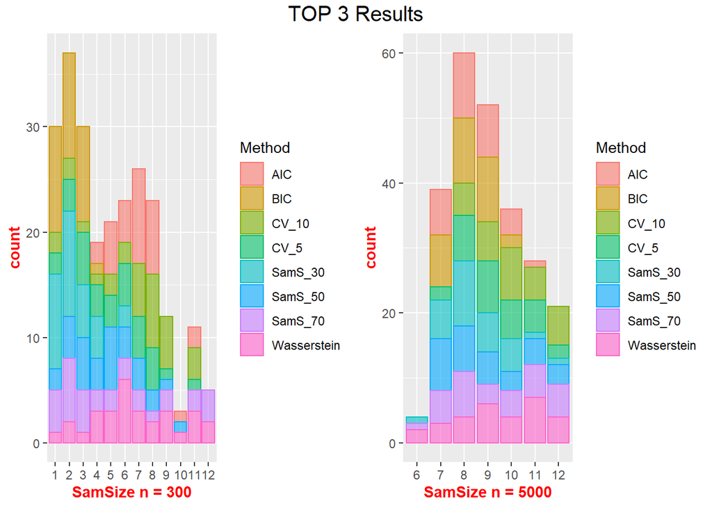

Below is it possible to see the results grouped by metric. Be aware that the histograms are computed on the top 3 results only.

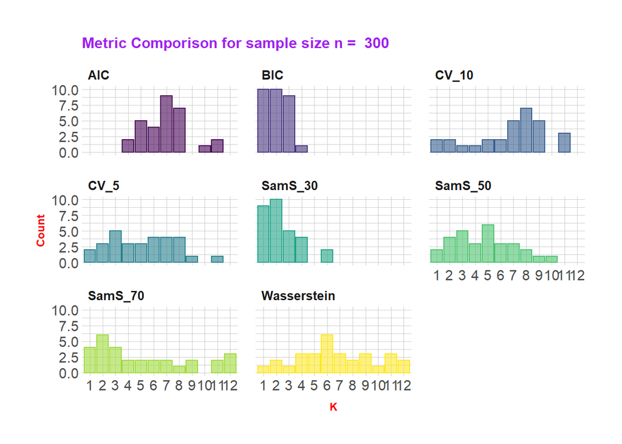

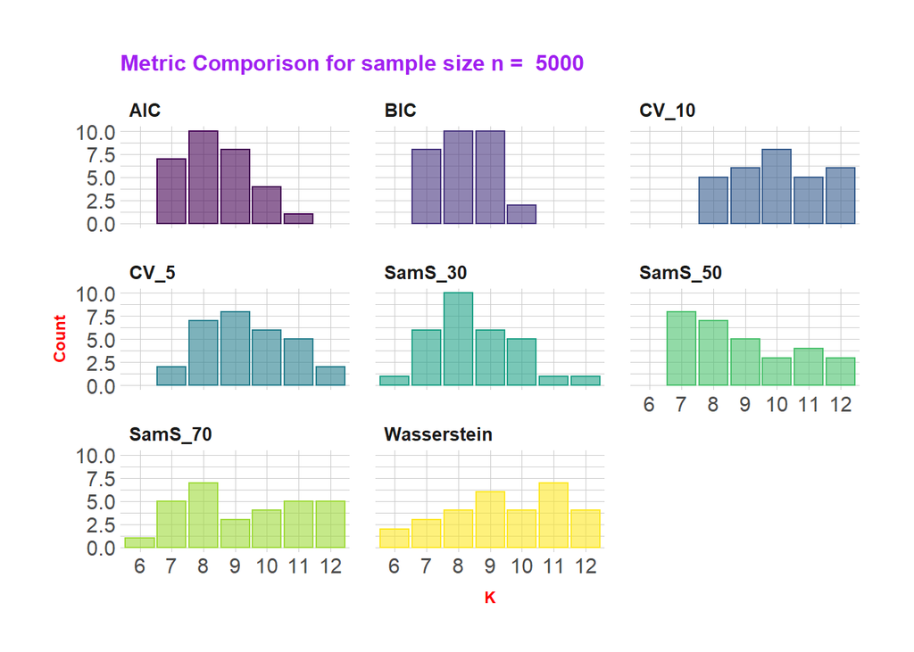

### Appendix A

The graph on the left shows the whole optimization by looking at the deviance, whereas the graph on the right is the same but without the first iteration. This allows us to show the phenomenon we mentioned in Section 2, where between 50 and 100 iterations the improvement is very small. This means that, in this case, a simple early stopping that takes a look at the deviance in few consecutive iterations could miss a next very good improvement.

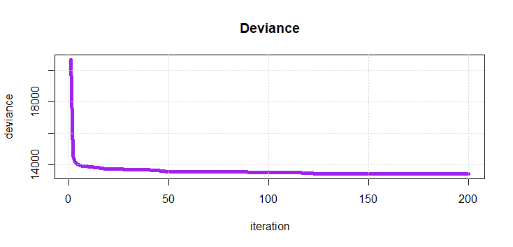

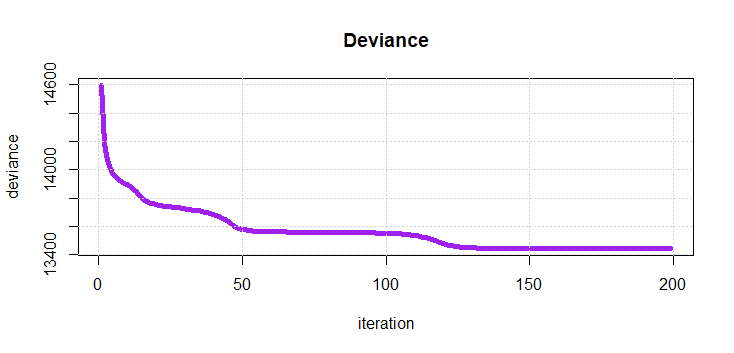

Deviance

### Appendix B

[figure not shown]

[figure not shown]

[figure not shown]

[figure not shown]

[figure not shown]

Fit examples

### Appendix C

| Method | Small Sample 1 1st(1) | Small Sample 1 2nd(1) | Small Sample 1 3rd(1) | Small Sample 2 1st(2) | Small Sample 2 2nd(2) | Small Sample 2 3rd(2) | Small Sample 3 1st(3) | Small Sample 3 2nd(3) | Small Sample 3 3rd(3) | Small Sample 4 1st(4) | Small Sample 4 2nd(4) | Small Sample 4 3rd(4) | Small Sample 5 1st(5) | Small Sample 5 2nd(5) | Small Sample 5 3rd(5) | Small Sample 6 1st(6) | Small Sample 6 2nd(6) | Small Sample 6 3rd(6) | Small Sample 7 1st(7) | Small Sample 7 2nd(7) | Small Sample 7 3rd(7) | Small Sample 8 1st(8) | Small Sample 8 2nd(8) | Small Sample 8 3rd(8) | Small Sample 9 1st(9) | Small Sample 9 2nd(9) | Small Sample 9 3rd(9) | Small Sample 10 1st(10) | Small Sample 10 2nd(10) | … |
| --- | --- | --- | --- | --- | --- | --- | --- | --- | --- | --- | --- | --- | --- | --- | --- | --- | --- | --- | --- | --- | --- | --- | --- | --- | --- | --- | --- | --- | --- | --- |
| AIC | 7 | 5 | 8 | 7 | 8 | 6 | 5 | 6 | 7 | 6 | 7 | 11 | 5 | 7 | 8 | 8 | 7 | 11 | 8 | 10 | 6 | 4 | 5 | 7 | 4 | 8 | 7 | 8 | 7 | … |
| BIC | 2 | 1 | 3 | 1 | 2 | 3 | 1 | 3 | 2 | 2 | 1 | 3 | 3 | 2 | 1 | 1 | 2 | 3 | 1 | 2 | 3 | 1 | 2 | 3 | 1 | 2 | 4 | 1 | 2 | … |
| SamS_30 | 1 | 2 | 3 | 1 | 2 | 3 | 1 | 4 | 2 | 6 | 2 | 4 | 3 | 2 | 1 | 1 | 2 | 4 | 2 | 1 | 3 | 1 | 2 | 6 | 2 | 1 | 3 | 1 | 4 | … |
| SamS_50 | 4 | 6 | 5 | 2 | 7 | 4 | 1 | 2 | 3 | 2 | 5 | 3 | 5 | 6 | 4 | 8 | 10 | 9 | 5 | 3 | 7 | 5 | 8 | 7 | 1 | 3 | 2 | 6 | 5 | … |
| SamS_70 | 1 | 2 | 3 | 7 | 3 | 2 | 1 | 2 | 3 | 11 | 12 | 9 | 7 | 5 | 9 | 6 | 1 | 2 | 2 | 4 | 5 | 11 | 12 | 4 | 1 | 2 | 3 | 12 | 8 | … |
| CV_5 | 4 | 6 | 3 | 5 | 2 | 3 | 7 | 8 | 9 | 4 | 3 | 5 | 8 | 7 | 11 | 6 | 7 | 5 | 1 | 3 | 2 | 8 | 1 | 2 | 7 | 6 | 8 | 6 | 3 | … |
| CV_10 | 11 | 8 | 7 | 8 | 1 | 7 | 7 | 8 | 9 | 9 | 8 | 7 | 7 | 8 | 11 | 6 | 5 | 9 | 2 | 1 | 3 | 8 | 2 | 4 | 8 | 9 | 5 | 11 | 9 | … |
| Wasserstein | 7 | 9 | 5 | 5 | 6 | 11 | 8 | 6 | 7 | 1 | 12 | 11 | 2 | 3 | 6 | 5 | 10 | 6 | 7 | 6 | 12 | 2 | 4 | 9 | 9 | 8 | 4 | 6 | 4 | … |

| Method | Big Sample 1 1st(11) | Big Sample 1 2nd(11) | Big Sample 1 3rd(11) | Big Sample 2 1st(12) | Big Sample 2 2nd(12) | Big Sample 2 3rd(12) | Big Sample 3 1st(13) | Big Sample 3 2nd(13) | Big Sample 3 3rd(13) | Big Sample 4 1st(14) | Big Sample 4 2nd(14) | Big Sample 4 3rd(14) | Big Sample 5 1st(15) | Big Sample 5 2nd(15) | Big Sample 5 3rd(15) | Big Sample 6 1st(16) | Big Sample 6 2nd(16) | Big Sample 6 3rd(16) | Big Sample 7 1st(17) | Big Sample 7 2nd(17) | Big Sample 7 3rd(17) | Big Sample 8 1st(18) | Big Sample 8 2nd(18) | Big Sample 8 3rd(18) | Big Sample 9 1st(19) | Big Sample 9 2nd(19) | Big Sample 9 3rd(19) | Big Sample 10 1st(20) | Big Sample 10 2nd(20) | … |
| --- | --- | --- | --- | --- | --- | --- | --- | --- | --- | --- | --- | --- | --- | --- | --- | --- | --- | --- | --- | --- | --- | --- | --- | --- | --- | --- | --- | --- | --- | --- |
| AIC | 8 | 7 | 9 | 8 | 9 | 10 | 7 | 8 | 9 | 7 | 8 | 10 | 7 | 8 | 9 | 8 | 9 | 10 | 9 | 8 | 11 | 7 | 8 | 9 | 8 | 7 | 10 | 7 | 9 | … |
| BIC | 7 | 8 | 9 | 8 | 7 | 9 | 7 | 8 | 9 | 7 | 8 | 9 | 7 | 8 | 9 | 8 | 9 | 10 | 8 | 9 | 10 | 7 | 8 | 9 | 7 | 8 | 9 | 7 | 8 | … |
| SamS_30 | 8 | 10 | 9 | 7 | 9 | 8 | 7 | 8 | 9 | 8 | 12 | 10 | 6 | 8 | 7 | 8 | 10 | 9 | 7 | 8 | 10 | 7 | 8 | 11 | 10 | 9 | 8 | 9 | 7 | … |
| SamS_50 | 7 | 12 | 8 | 11 | 7 | 8 | 7 | 8 | 9 | 11 | 12 | 8 | 9 | 7 | 11 | 7 | 9 | 10 | 7 | 8 | 9 | 10 | 7 | 8 | 7 | 8 | 11 | 12 | 9 | … |
| SamS_70 | 8 | 11 | 10 | 11 | 8 | 12 | 11 | 12 | 7 | 10 | 7 | 8 | 12 | 9 | 8 | 12 | 9 | 11 | 6 | 7 | 8 | 11 | 12 | 7 | 9 | 10 | 8 | 8 | 10 | … |
| CV_5 | 7 | 9 | 10 | 11 | 10 | 8 | 8 | 12 | 9 | 8 | 9 | 11 | 8 | 9 | 10 | 8 | 10 | 9 | 8 | 9 | 11 | 10 | 11 | 9 | 11 | 9 | 10 | 7 | 8 | … |
| CV_10 | 9 | 10 | 12 | 10 | 9 | 11 | 8 | 11 | 10 | 8 | 11 | 12 | 9 | 10 | 8 | 10 | 8 | 12 | 12 | 11 | 10 | 9 | 10 | 12 | 11 | 9 | 12 | 8 | 10 | … |
| Wasserstein | 9 | 12 | 8 | 11 | 7 | 10 | 9 | 10 | 11 | 8 | 7 | 9 | 6 | 10 | 7 | 9 | 12 | 11 | 6 | 12 | 11 | 11 | 12 | 8 | 11 | 9 | 8 | 9 | 10 | … |